# Reconnaissance Faciale associée à une base de données :

En direct _ Vidéo Webcam.

[figure not shown]

## * Recommandations d installation d'Opencv :

POUR INSTALLER OPENCV, il faut tenir compte de la version installée de Python.. Pour ma part, je suis Python 3.7.4 il faut donc que je récupère le fichier Opencv contrib correspondant : " opencv_python-4.1.2-cp37-cp37m-win_amd64.whl " .. en effet dans ce fichier on voit écrit cp37 qui correspond à ma version python .. le win pour windows et amd64 pour le 64bits ==> on trouve ces contrib au site suivant : " https://www.lfd.uci.edu/~gohlke/pythonlibs/#opencv " il faut placer ce fichier téléchargé là ou se trouve votre fichier python.exe, pour moi, cela se trouve ici : C:\ProgramData\Anaconda3 --> Puis, ouvrir cmd en tant qu'administrateur .. --> Placez-vous à l'endroit où vous avez copiez le ficher téléchargé précédemment avec la commande : cd C:\ProgramData\Anaconda3 Préparez le terrain pour Opencv en installant, (si ce n'est pas déjà fait !), numpy et matplotlib (pip install numpy, pip install matplotlib) Enfin : faire : pip3 install opencv_python-4.1.2-cp37-cp37m-win_amd64.whl ou : pip install opencv_python-4.1.2-cp37-cp37m-win_amd64.whl Et voilà ! Redémarrer Relancez un prompt, demandez python : >>>python et écrire la commande python : import cv2  
Si tout se passe bien, il ne doit pas y avoir de message d'erreur !!

Puis, Il faut installer les fichiers haarcascades pour la reconnaissance par ordi : --> il se trouvent soit en allant dans le site officiel d'Opencv Release : https://opencv.org/releases/ .. puis chercher sa version d'opencv, moi c'est opencv 4.1.2 : et dans l'encadré opencv 4.1.2, cliquez sur source .. .. dès lors se télécharge le dossier zippé d'opencv, dézipez le dossier.. .. puis dedans : data\haarcascades : vous trouverez le dossier contenant toutes les haarcascades .. Vous devrez alors placer le fichier d'intérêt (ex : haarcascade_frontalface_alt.xml) là où se trouve l'algorithme qui l'utilise !

Solution : Après blocage de : " recognizer=cv2.createLBPHFaceRecognizer(); " --> le site suivant : " https://stackoverflow.com/questions/44633378/attributeerror-module-cv2-cv2-has-no-attribute-createlbphfacerecognizer " --> propose de remplacer cette ligne par : --> recognizer=cv2.face.LBPHFaceRecognizer_create(); --> Attention, si on est sur une version d'Opencv >4, il faut alors réinstaller opencv : --> le site propose..et ça marche !! : --> Dans le promt administrateur : faire : python , puis : python -m pip install --user opencv-contrib-python --> Ensuite, on redémarre l'ordi et la ligne recognizer=cv2.face.LBPHFaceRecognizer_create(); fonctionne !

# - - - - - - - - - - - - - - - - - - - - - - - - - - - - - - - - - - - - - - - - - - - - - - - - - - - - - - - - - - - - - - -

# --> Organisation des dossiers et des fichiers :

# 1ère partie : Création de la base de données (BD) de reconnaissance faciale :

--> Téléchargez (si ce n'est pas déjà fait) SQLiteStudio : Dans Download, choisir la version correspondant à votre ordinateur.  
--> Dézippez le dossier, puis repérez le fichier SQLiteStudio.exe et ouvrez le ;  
--> Dans la barre de menu, Cliquez sur 'DataBase', et choisir 'Add a DataBase' : une fenêtre s'ouvre : Dans File, écrire le nom de la BD : 'FaceBase'.  
--> Cliquez sur le '+' en vert (Create a new Datafile), et choisir l'emplacement de son enregistrement : Dans le dossier 'X' où se trouve le fichier Jupyter.  
--> Faire 'Save', puis 'OK'  
--> Dans la colonne de gauche, on observe le nom 'FaceBase' : double cliquez dessus, puis doucle cliquez sur 'table' juste en dessous : une table vide s'ouvre.  
--> Dans la barre de menu, cliquez sur l'icône 'Create a new table', et renseignez alors, dessous dans l'encadré, le 'Table name' : écrire 'People', et validez ;  
--> Cliquez alors sur l'icône 'Add column' : une fenêtre 'column' s'ouvre ;  
--> Renseignez l'encadré 'Column name' par 'ID', l'encadré 'Data type' par 'INT', puis cochez 'Primary Key' car c'est l'ID qui servira de matricule aux infos d'une personne, cochez aussi 'Not Null', enfin faîtes 'OK' ;  
--> Cliquez à nouveau sur l'icône 'Add column' : une fenêtre 'column' s'ouvre ;  
--> Renseignez l'encadré 'Column name' par 'Name', l'encadré 'Data type' par 'STRING', cochez aussi 'Not Null', enfin faîtes 'OK' ;  
--> Cliquez à nouveau sur l'icône 'Add column' : une fenêtre 'column' s'ouvre ;  
--> Renseignez l'encadré 'Column name' par 'Age', l'encadré 'Data type' par 'INT', enfin faîtes 'OK' ;  
--> Cliquez à nouveau sur l'icône 'Add column' : une fenêtre 'column' s'ouvre ;  
--> Renseignez l'encadré 'Column name' par 'Genre', l'encadré 'Data type' par 'TEXT', enfin faîtes 'OK' ;  
--> Cliquez à nouveau sur l'icône 'Add column' : une fenêtre 'column' s'ouvre ;  
--> Renseignez l'encadré 'Column name' par 'Profession', l'encadré 'Data type' par 'TEXT', enfin faîtes 'OK' ;  
==> Cochez alors sur la coche verte (commit structure changes) du sous-onglet 'structure', et faîtes 'ok'  
==> C'est tout ! L'algorythme jupyter qui suit se chargera d'initier les personnes (id et name) dans la base de données.. Ce sera à vous, plus tard, de remplir les autres cases du tableau (en oubliant pas de cocher la coche verte au dessus du tableau pour valider les données).

# 2ème partie : Captures de photos d'identification d'un individu avec id défini

```python
# -*- coding: utf-8 -*-

import cv2
import sqlite3
import numpy as np

faceDetect = cv2.CascadeClassifier("haarcascade_frontalface_default.xml");
cam=cv2.VideoCapture(0);

def insertOrUpdate(Id, Name):
    conn=sqlite3.connect("FaceBase.db")
    cmd="SELECT * FROM People WHERE ID="+str(Id)
    cursor=conn.execute(cmd)
    isRecordExist=0
    for row in cursor:
        isRecordExist=1
    if(isRecordExist==1):
        cmd="UPDATE People SET Name "+srt(Name)+" WHERE ID="+srt(Id)
    else:
        cmd="INSERT INTO People(Id, Name) Values("+str(Id)+","+str(Name)+")"
    conn.execute(cmd)
    conn.commit()
    conn.close()

id=input("Entrez un N° d'id : ")
name=input("Entrez un nom : ")
insertOrUpdate(id, name)


sampleNum=0
while(True):
    ret,img=cam.read();
    gray=cv2.cvtColor(img,cv2.COLOR_BGR2GRAY)
    faces=faceDetect.detectMultiScale(gray,1.3,5);
    for (x,y,w,h) in faces:
        sampleNum=sampleNum+1
        cv2.imwrite("dataSet/User."+str(id) +"."+str(sampleNum)+".jpg", gray[y:y+h, x:x+w])
        cv2.rectangle(img, (x,y), (x+w, y+h), (0, 255, 0), 2 )
        cv2.waitKey(100);
    cv2.imshow("Face", img);
    cv2.waitKey(1);
    if(sampleNum>100):
        break
cam.release()
cv2.destroyAllWindows()
```

# 3ème partie : Entrainement de l'algorithme pour la détection des visages photographiés présents dans le dossier 'dataset' :

```python
# -*- coding: utf-8 -*-

import os
import cv2
import numpy as np
from PIL import Image
import sqlite3

#0# recognizer=cv2.createLBPHFaceRecognizer();
recognizer=cv2.face.LBPHFaceRecognizer_create();
#1# recognizer=cv2.face.LBPHFaceRecognizer_create();

path="dataSet"

def getImagesWithID(path):
    imagePaths=[os.path.join(path,f) for f in os.listdir(path)]
    faces=[]
    IDs=[]
    for imagePath in imagePaths:
        faceImg=Image.open(imagePath).convert("L");
        faceNp=np.array(faceImg, "uint8")
        ID=int(os.path.split(imagePath) [-1].split(".") [1])
        faces.append(faceNp)
        IDs.append(ID)
        cv2.imshow("training",faceNp)
        cv2.waitKey(10)

        #return np.array(IDs), faces
    return np.array(IDs), faces

Ids , faces = getImagesWithID(path)
recognizer.train(faces, Ids)
recognizer.save("recognizer/trainningData.yml")
cv2.destroyAllWindows()
```

# 4ème partie : Lancement de la détection des visages en prise de vidéo directe :

--> Lancez la cellule suivante : FAIRE ' q ' POUR SORTIR DE LA VIDEO !

```python
# -*- coding: utf-8 -*-
"""
Created on Fri Feb 14 11:12:18 2020

@author: dfial
"""

import cv2
import numpy as np
import sqlite3

faceDetect = cv2.CascadeClassifier("haarcascade_frontalface_default.xml");
cam=cv2.VideoCapture(0);
rec=cv2.face.LBPHFaceRecognizer_create();
rec.read("recognizer/trainningData.yml")
path="dataSet"

def getProfile(id):
    conn=sqlite3.connect("FaceBase.db")
    cmd="SELECT * FROM People WHERE ID="+str(id)
    cursor=conn.execute(cmd)
    profile=None
    for row in cursor:
        profile=row
    conn.close()
    return profile


#id=[]
id=0

#font=cv2.cv.InitFont(cv2.cv.CV_FONT_HERSHEY_COMPLEX_SMALL, 5,1,0,4)
#font=cv2.FONT_HERSHEY_COMPLEX_SIMPLEX
font = cv2.FONT_HERSHEY_SIMPLEX


##    font = cv2.FONT_HERSHEY_SIMPLEX
##    cv2.putText(img,"Cat",(x,y-10),font,0.55,(0,255,0),1)

while(True):
    ret,img=cam.read();
    gray=cv2.cvtColor(img,cv2.COLOR_BGR2GRAY)
    faces=faceDetect.detectMultiScale(gray,1.3,5);
    for (x,y,w,h) in faces:
        cv2.rectangle(img, (x,y), (x+w, y+h), (0, 255, 0), 2 )
        id,conf=rec.predict(gray[y:y+h, x:x+w])

        if conf>70:          # Plus la valeur de conf est élevé, moins l'algorithme a reconnu des visages
            id = "inconnu {0:.0f}%".format(round(100 - conf, 2)) # Cela évite qu'il affiche un prénom avec un % négatif
            cv2.putText(img,str(id),(x,y+h), font, 1, (255,255,255), 3);
        else:
            profile=getProfile(id)
            if (profile!=None):

            #cv2.cv.putText(cv2.cv.fromarray(img),str(id),(x,y+h), font, 255);
                cv2.putText(img,str(profile[1]),(x,y+h+30), font, 1, (255,255,255), 3);
                cv2.putText(img,str(profile[2]),(x,y+h+60), font, 1, (255,255,255), 3);
                cv2.putText(img,str(profile[3]),(x,y+h+90), font, 1, (255,255,255), 3);
                cv2.putText(img,str(profile[4]),(x,y+h+120), font, 1, (255,255,255), 3);

                ##  cv2.putText(im, str(Id), (x,y-40), font, 1, (255,255,255), 3)

    cv2.imshow("En direct _ Video Webcam", img);

    if(cv2.waitKey(1) ==ord("q")):
        break;
cam.release()
cv2.destroyAllWindows()
```

# 5ème partie : Détection des visages non masqués :

- Il faut d'abord installer le module pour la Synthèse vocale : --> Prompt Anaconda : pip install pyttsx3  
  --> Lancez la cellule suivante : FAIRE ' q ' POUR SORTIR DE LA VIDEO !  
  à tester avec/puis sans Masque : Changer les messages d'avertissement pour remettre son masque.

```
David n'a pas son masque au temps :  2020-12-23 11:44:38
```

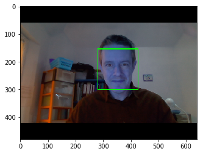

```python
# -*- coding: utf-8 -*-
"""
Created on Fri Feb 14 11:12:18 2020

@author: dfial
"""
DavidReconnu=0
DavidNbFois=0
MathiasReconnu=0
temps=0

import cv2
import numpy as np
import sqlite3   #  base de données

from time import gmtime, strftime
import pyttsx3  ## pour parler
from PIL import Image
from pylab import *
import matplotlib
from matplotlib.pyplot import *

import math
import imageio   ## pour sauvegarder 1 image jpg à partir d'1 array (Dans Edupython, il faut préalablement
## faire : Outils --> installer nouveau module --> 2 (pip) : imageio ##
from scipy.ndimage import filters
from scipy.ndimage import measurements,morphology # load image and threshold to make sure it is binary

################################################""
engine = pyttsx3.init()

# Set properties _before_ you add things to say
engine.setProperty('rate', 150)    # Speed percent (can go over 100)
engine.setProperty('volume', 0.9)  # Volume 0-1
#########################################################""

faceDetect = cv2.CascadeClassifier("haarcascade_frontalface_default.xml");
cam=cv2.VideoCapture(0);
rec=cv2.face.LBPHFaceRecognizer_create();
rec.read("recognizer/trainningData.yml")
path="dataSet"

def getProfile(id):
    conn=sqlite3.connect("FaceBase.db")
    cmd="SELECT * FROM People WHERE ID="+str(id)
    cursor=conn.execute(cmd)
    profile=None
    for row in cursor:
        profile=row
    conn.close()
    return profile


#id=[]
id=0
Daviddeb=time.time()

#font=cv2.cv.InitFont(cv2.cv.CV_FONT_HERSHEY_COMPLEX_SMALL, 5,1,0,4)
#font=cv2.FONT_HERSHEY_COMPLEX_SIMPLEX
font = cv2.FONT_HERSHEY_SIMPLEX


##    font = cv2.FONT_HERSHEY_SIMPLEX
##    cv2.putText(img,"Cat",(x,y-10),font,0.55,(0,255,0),1)

while(True):
    timetimehorloge=time.time()
    difDavid=timetimehorloge-Daviddeb
    if difDavid>80:
        print("difDavid=",difDavid)
    else:
        aa=2
    temps+=1
    ret,img=cam.read();
    gray=cv2.cvtColor(img,cv2.COLOR_BGR2GRAY)
    faces=faceDetect.detectMultiScale(gray,1.3,5);
    for (x,y,w,h) in faces:
        cv2.rectangle(img, (x,y), (x+w, y+h), (0, 255, 0), 2 )
        id,conf=rec.predict(gray[y:y+h, x:x+w])

        if conf>70:          # Plus la valeur de conf est élevé, moins l'algorithme a reconnu des visages
            id = "inconnu {0:.0f}%".format(round(100 - conf, 2)) # Cela évite qu'il affiche un prénom avec un % négatif
            cv2.putText(img,str(id),(x,y+h), font, 1, (255,255,255), 3);
        else:
            if id==1:
                if DavidReconnu==0:
                    horloge=strftime("%Y-%m-%d %H:%M:%S")
                    print("David n'a pas son masque au temps : ",horloge)
                    engine.say("Bonjour David!")
                    engine.say("Il faut mathre son masc!")
                    engine.runAndWait()
                    DavidReconnu+=1

                    secondeDavidReconnu=int(strftime("%S"))
                    minuteDavidReconnu=int(strftime("%M"))
                    minsecDavidReconnu=60*minuteDavidReconnu
                    minsecDavidReconnutot=minsecDavidReconnu+secondeDavidReconnu

                    capture=img
                    imshow(capture)
                    axis="off"
                    show()

            if id==1:
                if DavidReconnu==1:
                    horloge=strftime("%Y-%m-%d %H:%M:%S")

                    secondeDavidReconnuEnCour=int(strftime("%S"))
                    minuteDavidReconnuEnCour=int(strftime("%M"))
                    minsecDavidReconnuEnCour=60*minuteDavidReconnuEnCour
                    minsecDavidReconnutotEnCour=minsecDavidReconnuEnCour+secondeDavidReconnuEnCour

                    dif=minsecDavidReconnutotEnCour-minsecDavidReconnutot
                    if dif>7:
                        DavidReconnu=0
                    else:
                        aa=2




            elif id==2:
                if MathiasReconnu==0:
                    print("Mathias est reconnu")
                    MathiasReconnu+=1

                    capture=img
                    imshow(capture)
                    axis="off"
                    show()
            else:
                aa=2
            profile=getProfile(id)
            if (profile!=None):

            #cv2.cv.putText(cv2.cv.fromarray(img),str(id),(x,y+h), font, 255);
                cv2.putText(img,str(profile[1]),(x,y+h+30), font, 1, (255,255,255), 3);
                cv2.putText(img,str(profile[2]),(x,y+h+60), font, 1, (255,255,255), 3);
                cv2.putText(img,str(profile[3]),(x,y+h+90), font, 1, (255,255,255), 3);
                cv2.putText(img,str(profile[4]),(x,y+h+120), font, 1, (255,255,255), 3);

                ##  cv2.putText(im, str(Id), (x,y-40), font, 1, (255,255,255), 3)

    cv2.imshow("En direct _ Video Webcam", img);

    if(cv2.waitKey(1) ==ord("q")):
        break;
cam.release()
cv2.destroyAllWindows()
```

```python
Travail sur laffichage du temps
```

```python
horloge=strftime("%Y-%m-%d %H:%M:%S")
date = strftime("%A %d-%m-%Y")
heure = strftime("%H:%M:%S")
print("On est le : ",date,", et il est :",heure)
```

```python
Travail sur les comparaisons de temps
```

```python
import time
#a=time.time()
horloge=strftime("%Y-%m-%d %H:%M:%S")
secondea=int(strftime("%S"))
minutea=int(strftime("%M"))
minseca=60*minutea
minsecatot=minseca+secondea
#print ("a=",a)
print (horloge)
print("les secondes =",secondea)
print("les minutes =",minutea)
print("les minutes et les secondes en secondes =",minsecatot)
for a in range(100000000):
    aa=2
#b=time.time()
horloge=strftime("%Y-%m-%d %H:%M:%S")
secondeb=int(strftime("%S"))
minuteb=int(strftime("%M"))
minsecb=60*minuteb
minsecbtot=minsecb+secondeb
#print ("b=",b)
print (horloge)
print("les secondes =",secondeb)
print("les minutes =",minuteb)
print("les minutes et les secondes en secondes =",minsecbtot)
dif=secondeb-secondea
print("différence de temps sur les secondes uniquement =",dif,"secondes")
dif2=minsecbtot-minsecatot
print("différence de temps sur les secondes totales =",dif2,"secondes")
```